# Curso online en vivo: Introducción a R para Principiantes

[figure not shown]

## ¿Qué obtengo al inscribirme?

1. Acceso al curso online en vivo *“Introducción a R para Principiantes”*, el cual consiste en 3 sesiones de 1 hora y 30 minutos cada una. Este es un curso teórico/práctico.
2. Acceso **GRATIS** al curso *Introducción a ecología del paisaje en R*, el cuál es un curso asincrónico (son videos grabados en la plataforma Udemy). En este curso vas a poder practicar lo aprendido (más información click [acá](https://www.udemy.com/course/introduccion-a-ecologia-del-paisaje-en-r/?referralCode=2486BE25C1BB4224A397))
3. Acceso **GRATIS** al curso *Introducción a la Programación en R*, el cuál es un curso asincrónico (son videos grabados en la plataforma *Udemy*). En este curso vas a poder practicar lo aprendido (más información click [acá](https://www.udemy.com/course/introduccion-a-r-gratis/?referralCode=36D0BFEDBFB3B24AB3A2))

## ¿Qué aprenderé?

- Manejo del lenguaje de programación R
- Análisis de archivos Excel/CSV
- Limpieza de de datos usando Tidyverse
- Gráficos de alto nivel con el paquete ggplot2

## ¿Qué ventajas me entrega R?

- Analizar grandes bases de datos de forma veloz
- No tendrás que realizar el mismo procedimiento una y otra vez de forma lenta y agotadora.
- A través de códigos de programación podrás replicar tareas y funciones especificas todas las veces que quieras y de una forma fácil.
- Crear gráficos de alto nivel para reportes/publicaciones científicas

## ¿En qué fecha es el curso en vivo?

14, 16 y 18 de junio. Desde las 19:00 hasta las 20:30 hrs. de Chile

## ¿Los cursos entregan certificado?

Si, los 3 cursos entregan certificado. No es necesario hacer un trabajo de aprobación para recibir el certificado.

## ¿Puedes contar un poco más sobre los cursos asincrónico de regalo?

Estos cursos tienen una metodología flexible, ya que estos son videos grabados que se encuentran en la plataforma Udemy, por lo que podrás avanzar cuando más te acomode.En estos cursos podrás reforzar y practicar lo aprendido en el curso realizado en vivo.

Puntos importantes:

- Una vez que te inscribes al curso, tienes acceso de por vida al contenido, por lo que puedes avanzar en el curso a tu propio ritmo.
- Los cursos tienen tareas para practicar lo aprendido. Las tareas no son obligatorias, pero se recomienda que las realices, ya que para dominar lo aprendido en los cursos tienes que practicar y practicar. Recuerda que la práctica hace al maestro.
- Una vez finalizado el curso, recibes un certificado de aprobación del curso.

## No soy de Chile, ¿puedo participar igual?

Si, este curso está abierto a personas de todos los países del mundo.

## ¿Cómo sé si el curso es bueno?

Acá puedes ver algunos comentarios de personas que han realizado los cursos

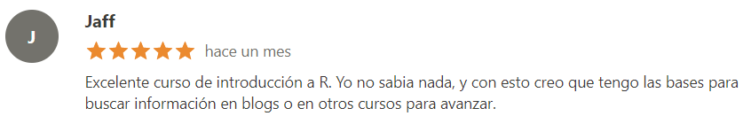

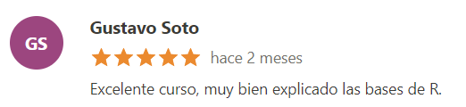

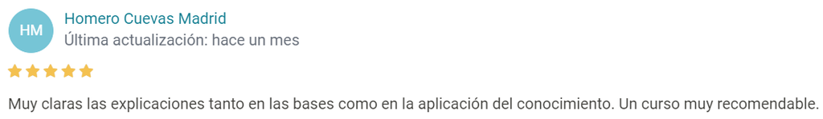

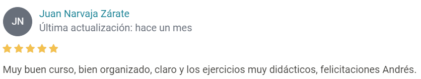

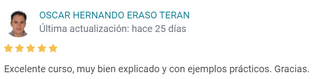

## Cuál es el valor del curso?

- Estudiantes y desempleados: 25.000 CLP (Extranjeros: 40 USD)
- Público general: 35.000 CLP (Extranjeros: 55 USD)

## ¿Cómo se realiza el pago?

- Personas de Chile: a través de transferencia bancaria
- Otros países: a través de PayPal (sistema súper seguro para transferir dinero desde el extranjero)

*Estos datos serán entregados una vez que mandes un mail para inscribirte.

## Soy extranjero y nunca he usado PayPal

No te preocupes, es un sistema súper seguro. Hemos recibido transferencias de dinero de muchos países y nunca hemos tenido problemas con PayPal. Sólo necesitas una tarjeta de crédito para vincularla con tu cuenta de PayPal.

Si quieres más información de como funciona PayPal, haz click [acá](https://www.paypal.com/cl/webapps/mpp/what-is-paypal)

## ¿Qué conocimientos previos necesito?

- No es necesario ningún conocimiento previo

## ¿Las clases serán grabadas?

Si, serán grabadas y compartidas a los asistentes en un carpeta de Google Drive

## ¿Qué puedo hacer si quiero participar, pero tengo problemas con la fecha?

Puedes inscribirte igual y ver los videos de las clases grabadas, ya que los videos de estas se comparten a los inscritos en un carpeta de Google Drive

## ¿Cómo es el programa de los contenidos del curso?

**1) Lunes 14/6:**

- Introducción a R

**2) Miércoles 16/6:**

- Estructuras de datos
- Introducción al análisis de alto nivel con Tidyverse

**3) Viernes 18/6:**

- Continuación Tidyverse
- Gráficos avanzados con ggplot2

## En qué plataforma se realizará el curso

Se realizará en *Zoom*

## ¿Quién dictará el curso?

Andrés Salazar, Ingeniero Agrónomo, Magíster en Recursos Naturales. Pontificia Universidad Católica de Chile

Pefil Linkedin: https://www.linkedin.com/in/andr%C3%A9s-salazar-6213b6163/

Página web: https://geostyle.github.io

## ¿Dónde me inscribo?

Escribe un mail a ajsalazar@uc.cl

Indicando:

**1)** País de residencia

**2)** Categoría: estudiante/desempleado o público general

**3)** Nivel de conocimientos previos en R o en otro lenguaje de programación (**no es necesario** tener conocimientos previos en R ni de otro lengiaje de programación)

Las preguntas de conocimientos previos son para saber **como guiar las clases** para que sea más fácil de aprender para los asistentes.

*GeoStyle, Chile. 2021*  
https://geostyle.github.io